# DSI_Data_Challenge

Dingxin Lu

9/29/2021

[my github link] https://github.com/sydneydlu98/DSI_Data_Challenge_1

# Setup

```r
## load in the required libraries
library(readr)
library(tidyverse)
library(here)
library(RColorBrewer)

## read in the data using here() function
state_milk_production <- read_csv(here("data/state_milk_production.csv"))
clean_cheese <- read_csv(here("data/clean_cheese.csv"))
fluid_milk_sales <- read_csv(here("data/fluid_milk_sales.csv"))
milk_products_facts <- read_csv(here("data/milk_products_facts.csv"))
milkcow_facts <- read_csv(here("data/milkcow_facts.csv"))

## disable scientific notation
options(scipen = 999)
```

# Figure 1

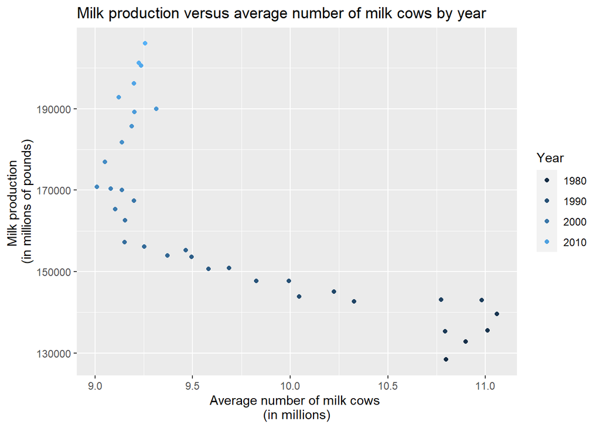

```r
## initiate ggplot for plotting graphs geom_point() is used
## to create scatter plots x,y axes and main title will be
## labeled with labs()
ggplot(milkcow_facts, aes(x = avg_milk_cow_number/1000000, y = milk_production_lbs/1000000)) +
    geom_point(aes(col = year)) + labs(x = "Average number of milk cows \n(in millions)",
    y = "Milk production \n(in millions of pounds)", title = "Milk production versus average number of milk cows by year") +
    guides(color = guide_legend(title = "Year"))  ## label and color the legend
```

Figure 1. This plot shows the milk production against average number of milk cows from the year 1980 to 2010. We can see in 1980, the average number of milk cows is around 11 millions, and that can produce 130 billion pounds of milk. Compared to in 2010, the average number of milk cow is only around 9 million but can produce around 210 billion pounds of milk. This makes sense as technology and skills improve over time, so we are able to produce more milk with less cows. In conclusion, from the year 1980 to 2010, the average number of milk cows decreases but the amount of milk produced increases massively.

# Figure 2

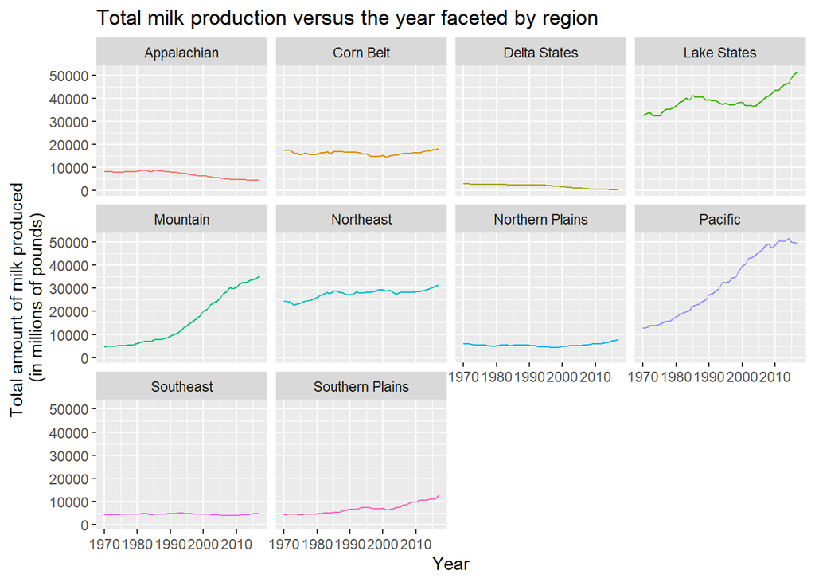

```r
## group region and milk as they are of our interest
## calculate the total amount of milk produced by using sum()
state_milk_production %>%
  group_by(region, year) %>%
  summarise(total_milk_produced = sum(milk_produced)) %>%

## initiate ggplot for plotting graphs
## geom_line() connects points in order of the variable on the x axis to create a line plot
## x,y axes and main title will be labeled with labs()
  ggplot(aes(x = year,
           y = total_milk_produced / 1000000)) +
  geom_line(aes(color = region)) + ## plot the line plot using different colors to differentiate the region
  facet_wrap( ~ region) + ## split a single plot into many related plots based on different regions
  labs(x ='Year',
       y ='Total amount of milk produced \n(in millions of pounds)',
       title ='Total milk production versus the year faceted by region') +
  theme(legend.position = "none") ## get rid of legend for this plot
```